# Sampling Notes - Niger

## Introduction

This file outlines the sampling strategy for Niger.

## General Notes on Sampling

The aim of the Global Education Policy Dashboard school survey is to produce nationally representative estimates, which will be able to detect changes in the indicators over time at a minimum power of 80% and with a 0.05 significance level. We also wish to detect differences by urban/rural location.

For our school survey, we will employ a two-stage random sample design, where in the first stage a sample of around 200 schools, based on local conditions, is drawn, chosen in advance by the Bank staff. In the second stage, a sample of teachers and students will be drawn to answer questions from our survey modules, chosen in the field. A total of 10 teachers will be sampled for absenteeism. Five teachers will be interviewed and given a content knowledge exam. Three 1st grade students will be assessed at random, and a classroom of 4th grade students will be assessed at random. Stratification will be based on the school’s urban/rural classification and based on region. When stratifying by region, we will work with our partners within the country to make sure we include all relevant geographical divisions.

For our Survey of Public Officials, we will sample a total of 200 public officials. Roughly 40 officials will be surveyed at the federal level, while 160 officials will be surveyed at the reginoal/district level. For selection of officials at the regional and district level, we will employ a cluster sampling strategy, where 12 Governorate offices are chosen at random from among the regions in which schools were sampled. Then among these 12 Governorates, we also select at random 12 Directorates from among the Directorates in which schools werer sampled. The result of this sampling approach is that for 12 clusters we will have links from the school to the Directorates office to the Governorate office to the central office. Within the Governorates/Directorates five or six officials will be sampled, including the head of organization, HR director, two division directors from finance and planning, and one or two randomly selected professional employees among the finance, planning, and one other service related department chosen at random. At the federal level, we will interview the HR director, finance director, planning director, and three randomly selected service focused departments. In addition to the directors of each of these departments, a sample of 9 professional employees will be chosen in each department at random on the day of the interview.

Sampling Approach for Global Education Policy Dashboard

This document will provide an overview of the sampling strategy used in the Global Education Policy Dashboard (GEPD) surveys, as well as remaining questions. New data for the dashboard will be collected using three main instruments: a School Survey, an Expert Survey, and a Survey of Public Officials. More information pertaining to each can be found below. The goal of the Global Education Policy Dashboard is to provide summary information at the national level on a set of 35 indicators and to allow countries to track progress on those indicators over a short time frame (every 2 years). Specifically, we aim to produce nationally representative estimates, which will be able to detect changes in the indicators over time at a minimum power of 80% and with a 0.05 significance level. We also wish to disaggregate by urban/rural.

School Survey: The School Survey will collect data primarily on Practices (the quality of service delivery in schools), but also on some de facto Policy and school-level Politics indicators. It will consist of streamlined versions of existing instruments—including SDI and SABER SD on teachers, 4th grade students, and inputs/infrastructure, TEACH on pedagogical practice, GECDD on school readiness of young children, and DWMS on management quality—together with new questions to fill gaps in those instruments. Though the number of modules is similar to the full version of SDI, the number of items within each module is significantly lower. In each country, this survey will be administered in a nationally representative sample of 250 schools, selected through stratified random sampling. As currently envisioned, the School Survey will include 8 short modules. Expert Survey: The Expert Survey will collect information to feed into the policy indicators. This survey will be filled out by key informants in each country, drawing on their knowledge to identify key elements of the policy framework (as in the SABER approach to policy-data collection that the Bank has used over the past 7 years). The survey will have 4 modules with each including approximately ten questions.

Survey of Public Officials: The Survey of Public Officials will collect information about the capacity and orientation of the bureaucracy, as well as political factors affecting education outcomes. This survey will be a streamlined and education-focused version of the civil-servant surveys that the Bank’s Bureaucracy Lab has implemented recently in several countries, and the dashboard team is collaborating closely with DEC and Governance GP staff to develop this instrument. As currently envisioned, the survey will be administered to a random sample of about 200 staff serving in the central education ministry and district education offices. It will include questions about technical and leadership skills, work environment, stakeholder engagement, clientelism, and attitudes and behaviors.

## Summary Statistics for Niger Schools Overall in Sampling Frame

| Summary Statistics for Sampling Frame variable | Summary Statistics for Sampling Frame mean | Summary Statistics for Sampling Frame sd | Summary Statistics for Sampling Frame p0 | Summary Statistics for Sampling Frame p25 | Summary Statistics for Sampling Frame p50 | Summary Statistics for Sampling Frame p75 | Summary Statistics for Sampling Frame p100 | Summary Statistics for Sampling Frame N | Summary Statistics for Sampling Frame n_missing | Summary Statistics for Sampling Frame complete_rate |
| --- | --- | --- | --- | --- | --- | --- | --- | --- | --- | --- |
| Total Male Students | 74.97 | 74.16 | 0 | 27 | 50 | 96.00 | 935 | 21,060 | 0 | 1.00 |
| Total Female Students | 66.84 | 71.34 | 0 | 23 | 43 | 82.00 | 953 | 21,060 | 0 | 1.00 |
| Total Students | 141.80 | 142.45 | 1 | 52 | 92 | 176.00 | 1,623 | 21,060 | 0 | 1.00 |
| Total 4th Grade Male Students | 20.63 | 14.77 | 0 | 10 | 18 | 27.00 | 170 | 21,060 | 10,764 | 0.49 |
| Total 4th Grade Female Students | 17.96 | 14.19 | 0 | 9 | 15 | 23.00 | 156 | 21,060 | 10,764 | 0.49 |
| Total 4th Grade Students | 38.60 | 27.10 | 0 | 21 | 33 | 47.25 | 256 | 21,060 | 10,764 | 0.49 |
| Total 1st Grade Male Students | 24.61 | 16.48 | 0 | 13 | 22 | 31.00 | 185 | 21,060 | 9,121 | 0.57 |
| Total 1st Grade Female Students | 22.53 | 15.89 | 0 | 12 | 20 | 29.00 | 186 | 21,060 | 9,121 | 0.57 |
| Total 1st Grade Students | 47.13 | 30.65 | 0 | 27 | 42 | 60.00 | 366 | 21,060 | 9,121 | 0.57 |
| Public Schools | 0.96 | 0.21 | 0 | 1 | 1 | 1.00 | 1 | 21,060 | 0 | 1.00 |
| Rural Schools | 0.82 | 0.39 | 0 | 1 | 1 | 1.00 | 1 | 21,060 | 0 | 1.00 |
| Basic Education School | 0.87 | 0.34 | 0 | 1 | 1 | 1.00 | 1 | 21,060 | 0 | 1.00 |

## Sampling Frame

```r
#restrict to schools of at least 15 students
df_filtered <- df %>%
  filter(total_students>=15) %>%
  filter(basic_education==1)

# merge LIRE database

lire_df <- read_excel(path = paste0(sampling_folder,"/Liste_Ecoles_Primaires_Projet_LIRE_GEPD.xlsx"),
                      sheet = "3000_ecoles_primaires_effsup50") %>%
  transmute(REGION=Drep,
         DEPARTEMENT=Departement,
         COMMUNE=commune,
         NOM_ETABLISSEMENT=NOM_ETABLISSEMENT) %>%
  mutate(LIRE="LIRE School")

lire_matchable <- lire_df %>%
  left_join(df_filtered %>% select(REGION, DEPARTEMENT, COMMUNE, village, NOM_ETABLISSEMENT, CODE_ADMINISTRATIF,CODE_ETABLISSEMENT, total_students, urban_rural ))
df_updated <- df_filtered %>%
  left_join(lire_df) %>%
  distinct(CODE_ETABLISSEMENT, .keep_all = TRUE)
#only able to match 2408 of the 3000 lire schools.
df_updated %>% group_by(LIRE) %>% summarise(n=n())
```

```
## # A tibble: 2 x 2
##   LIRE            n
##   <chr>       <int>
## 1 LIRE School  2407
## 2 <NA>        15605
```

From the 21060 schools in the original frame, we will restrict to schools with at least 15 students of primary age, and schools classified as “basic education” schools, as opposed to “Preschool Education” schools. This restriction eliminates 3048 schools.

```r
df_updated %>%
  dplyr::select(indicator_list2) %>%
  skim() %>%
  rename(variable=skim_variable) %>%
  rename_with(~str_replace(.,"numeric.","")) %>%
  mutate(N=frame_size) %>%
  dplyr::select(variable, mean, sd, p0, p25, p50, p75, p100,N, n_missing, complete_rate) %>%
  mutate(variable=factor(variable, levels=indicator_list2,
                         labels=indicator_labels2)) %>%
  arrange(match(variable, indicator_labels2)) %>%
  mutate(across(where(is.numeric), round,2)) %>%
  flextable() %>%
  add_header_lines("Summary Statistics for Sampling Frame") %>%
  theme_booktabs()
```

| Summary Statistics for Sampling Frame variable | Summary Statistics for Sampling Frame mean | Summary Statistics for Sampling Frame sd | Summary Statistics for Sampling Frame p0 | Summary Statistics for Sampling Frame p25 | Summary Statistics for Sampling Frame p50 | Summary Statistics for Sampling Frame p75 | Summary Statistics for Sampling Frame p100 | Summary Statistics for Sampling Frame N | Summary Statistics for Sampling Frame n_missing | Summary Statistics for Sampling Frame complete_rate |
| --- | --- | --- | --- | --- | --- | --- | --- | --- | --- | --- |
| Total Male Students | 82.65 | 76.93 | 0 | 31 | 57 | 107 | 935 | 21,060 | 0 | 1.00 |
| Total Female Students | 73.00 | 74.71 | 0 | 26 | 48 | 91 | 953 | 21,060 | 0 | 1.00 |
| Total Students | 155.65 | 148.31 | 15 | 60 | 105 | 197 | 1,623 | 21,060 | 0 | 1.00 |
| Total 4th Grade Male Students | 20.74 | 14.75 | 0 | 11 | 18 | 27 | 170 | 21,060 | 7,779 | 0.57 |
| Total 4th Grade Female Students | 18.06 | 14.18 | 0 | 9 | 15 | 23 | 156 | 21,060 | 7,779 | 0.57 |
| Total 4th Grade Students | 38.80 | 27.06 | 0 | 21 | 33 | 48 | 256 | 21,060 | 7,779 | 0.57 |
| Total 1st Grade Male Students | 24.75 | 16.45 | 0 | 14 | 22 | 31 | 185 | 21,060 | 6,151 | 0.66 |
| Total 1st Grade Female Students | 22.66 | 15.86 | 0 | 12 | 20 | 29 | 186 | 21,060 | 6,151 | 0.66 |
| Total 1st Grade Students | 47.40 | 30.57 | 0 | 28 | 42 | 60 | 366 | 21,060 | 6,151 | 0.66 |
| Public Schools | 0.97 | 0.16 | 0 | 1 | 1 | 1 | 1 | 21,060 | 0 | 1.00 |
| Rural Schools | 0.87 | 0.34 | 0 | 1 | 1 | 1 | 1 | 21,060 | 0 | 1.00 |
| Basic Education School | 1.00 | 0.00 | 1 | 1 | 1 | 1 | 1 | 21,060 | 0 | 1.00 |

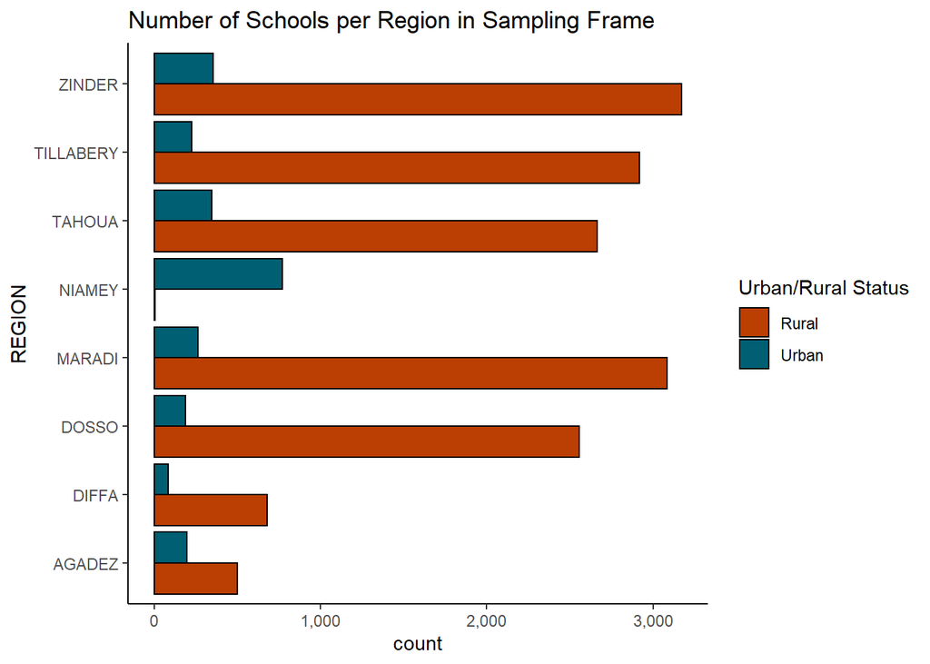

```r
ggplot(df_updated, aes(x=REGION, group=urban_rural, fill=urban_rural)) +
  geom_bar(color='black',
           position='dodge') +
  theme_classic() +
  scale_y_continuous(labels=scales::comma) +
  scale_fill_manual(
    values=c(
      'Rural'='#bb3e03',
      'Urban'='#005f73'
    )
  ) +
  labs(fill="Urban/Rural Status") +
  coord_flip() +
  ggtitle('Number of Schools per Region in Sampling Frame')
```

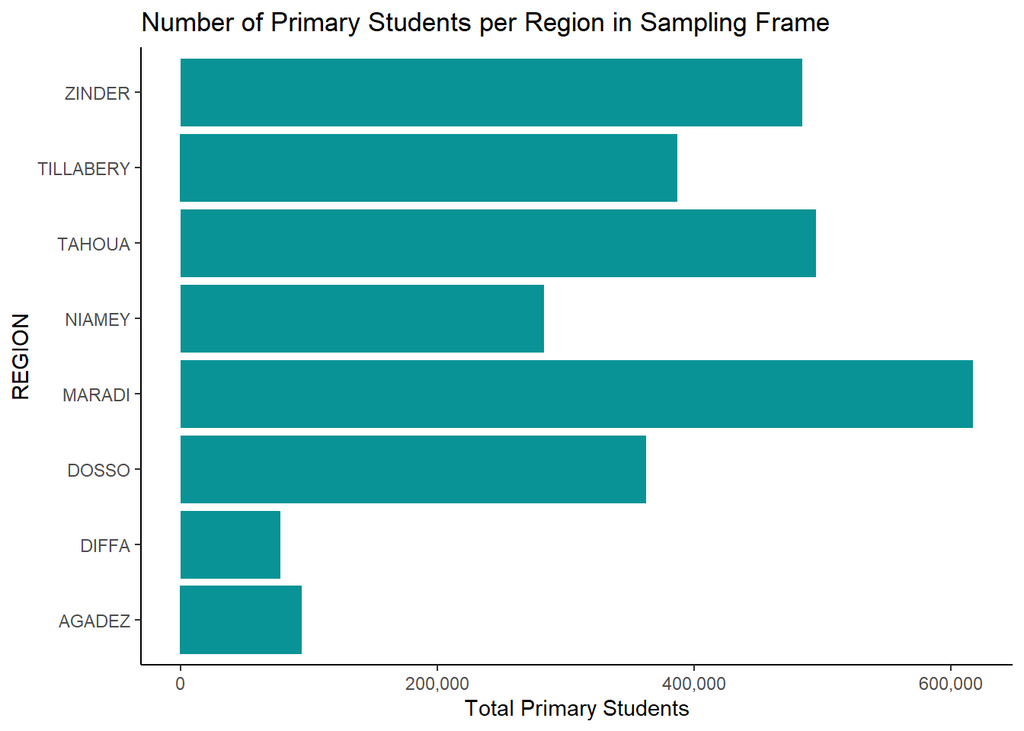

```r
ggplot(df_updated, aes(x=REGION, y=total_students)) +
  geom_col(fill="#0a9396") +
  theme_classic() +
  scale_y_continuous(labels=scales::comma) +
  ylab('Total Primary Students') +
  coord_flip() +
  ggtitle('Number of Primary Students per Region in Sampling Frame')
```

# Select the Sample

Stratification will be done on the basis of region and the urban/rural status of the school. The number of schools per strata is based on the sum of primary students (total_students) in the school. The schools chosen within each strata are done with probability proportional to the total number of primary students in the school.

```r
#in this code chunk, the number of schools to be selected in each stratum will be set.  This will be based on the population of the stratum.
# The strata are based on the 8 regions and urban/rural status
set.seed(2435345)

strata_size <- df_updated %>%
  group_by(REGION,urban_rural) %>%
  summarise(
    n_schools=n(),
    n_students=sum(total_students),
    share_students=n_students/sum(df_updated$total_students),
    exp_num_schools=200*share_students,
    ini_num_schools=round(exp_num_schools,0)
  ) %>%
  ungroup() %>%
  sample_n(nrow(.)) #randomly order the rows
#pick number of schools in each strata so that total adds to 200
# get vector of exp_num_schools
num_schools <- strata_size$ini_num_schools

#do a while loop sequentially randomly adding or subtracting a school to the list for a randomly selected strata until total is 200
while (sum(num_schools)!=200) {

  if (sum(num_schools)<200) {

    nr <- round(runif(n=1,min=1,max=16),0) #randomly choose integer between 0 and 16
    extra_schools <- rep(0,16) #create vector of 0s
    extra_schools[nr] <- 1 # for one random strata add one.
    num_schools <- num_schools + extra_schools #add to list of schools.
  } else {
    nr <- round(runif(n=1,min=1,max=16),0) #randomly choose integer between 0 and 16
    extra_schools <- rep(0,16) #create vector of 0s
    extra_schools[nr] <- -1 # for one random strata add one.
    num_schools <- num_schools + extra_schools #add to list of schools.
  }

}


sum(num_schools)
```

```
## [1] 200
```

```r
strata_size$num_schools <- num_schools

sum(strata_size$chosen_num_schools)
```

```
## [1] 0
```

```r
# There are 34 schools, so we need to choose 6 more randomly
districts <- strata_size %>%
  group_by(REGION,urban_rural) %>%
  summarise(num_schools=sum(num_schools),
            n_students=sum(n_students))
districts %>% group_by(urban_rural) %>% summarise(num_schools=sum(num_schools))
```

```
## # A tibble: 2 x 2
##   urban_rural num_schools
##   <chr>             <dbl>
## 1 Rural               145
## 2 Urban                55
```

```r
#now choose the schools within strata
school_sample_df <- df_updated %>%
  left_join(strata_size) %>%
  group_by(REGION,urban_rural) %>%
  sample_n(size=num_schools, weight=total_students)
#write_excel_csv(school_sample_df, paste(sampling_folder, '/sample_schools_', Sys.Date(),  '.csv', sep=""))
```

```r
# The strata are based on the 8 regions and urban/rural status
set.seed(243545)


  ## Adding the 70 LIRE schools

  lire_sampled_first <- school_sample_df %>% filter(LIRE == "LIRE School") %>% pull(CODE_ETABLISSEMENT)

  lire_matchable_sample <- lire_matchable %>% filter(!CODE_ETABLISSEMENT %in%  lire_sampled_first)


  strata_size_lire <- lire_matchable_sample %>%
  filter(!is.na(urban_rural)) %>%
  group_by(REGION,urban_rural ) %>%
  summarise(
    n_schools=n(),
    n_students=sum(total_students),
    share_students=n_students/sum(lire_matchable_sample$total_students, na.rm=T),
    exp_num_schools=70*share_students,
    ini_num_schools=round(exp_num_schools,0)
  ) %>%
  ungroup() %>%
  sample_n(nrow(.)) #randomly order the rows
    #pick number of schools in each strata so that total adds to 200
  # get vector of exp_num_schools
  num_schools <- strata_size_lire$ini_num_schools

  #do a while loop sequentially randomly adding or subtracting a school to the list for a randomly selected strata until total is 200
  while (sum(num_schools)!=70) {

    if (sum(num_schools)<70) {

      nr <- round(runif(n=1,min=1,max=10),0) #randomly choose integer between 0 and 16
      extra_schools <- rep(0,10) #create vector of 0s
      extra_schools[nr] <- 1 # for one random strata add one.
      num_schools <- num_schools + extra_schools #add to list of schools.
    } else {
      nr <- round(runif(n=1,min=1,max=10),0) #randomly choose integer between 0 and 16
      extra_schools <- rep(0,10) #create vector of 0s
      extra_schools[nr] <- -1 # for one random strata add one.
      num_schools <- num_schools + extra_schools #add to list of schools.
    }

  }


  sum(num_schools)
```

```
## [1] 70
```

```r
  strata_size_lire$num_schools <- num_schools

  sum(strata_size_lire$num_schools)
```

```
## [1] 70
```

```r
  # There are 34 schools, so we need to choose 6 more randomly
  districts <- strata_size_lire %>%
    group_by(REGION,urban_rural) %>%
    summarise(num_schools=sum(num_schools),
              n_students=sum(n_students))
   #now choose the schools LIRE within strata
  school_sample_LIRE_df <- lire_matchable_sample %>%
    filter(!is.na(total_students)) %>%
    left_join(strata_size_lire) %>%
    group_by(REGION,urban_rural) %>%
    sample_n(size=num_schools, weight=total_students)
#append lLIRE schools

  sample_final <- school_sample_df %>%
    bind_rows(school_sample_LIRE_df)


    write_excel_csv(sample_final, paste(sampling_folder, '/sample_schools_', Sys.Date(),  '.csv', sep=""))
```

# Replacement Schools

Below is a list of replacement schools for each sampled school. Replacement schools were randomly selected among the set of schools in the district, not including the orginally sampled schools. Each row contains the school name, location, and other information for each replacement school. In the final 5 columns of the database is the school code, school name, region, and district of the originally sampled school for which this school serves as a replacement.

|  | urban_rural | LIRE | NOM_ETABLISSEMENT | CODE_ETABLISSEMENT | REGION | replaced_NOM_ETABLISSEMENT | replaced_CODE_ETABLISSEMENT | replaced_REGION |
| --- | --- | --- | --- | --- | --- | --- | --- | --- |
| 1 | Rural |  | Anoun Alher Medersa | 1595 | AGADEZ | Abardac/Talat | 1560 | AGADEZ |
| 2 | Rural |  | Dirkou carré | 1366 | AGADEZ | Abardac/Talat | 1560 | AGADEZ |
| 3 | Rural |  | Emachalwane | 1652 | AGADEZ | Abardac/Talat | 1560 | AGADEZ |
| 4 | Rural |  | Medersa Guermawane | 134 | AGADEZ | Tessilit/M | 1734 | AGADEZ |
| 5 | Rural |  | Nabaro Alwat | 1605 | AGADEZ | Tessilit/M | 1734 | AGADEZ |
| 6 | Rural |  | Tassalam Salam | 1290 | AGADEZ | Tessilit/M | 1734 | AGADEZ |
| 7 | Urban |  | Abzine 2 | 1168 | AGADEZ | Aéroport | 1121 | AGADEZ |
| 8 | Urban |  | Arlit Boukoki 4 | 1248 | AGADEZ | Aéroport | 1121 | AGADEZ |
| 9 | Urban |  | ARLIT QUARTIER 1 | 1215 | AGADEZ | Aéroport | 1121 | AGADEZ |
| 10 | Urban |  | DAGMANET 5 | 1149 | AGADEZ | Arlit Boukoki Nord 3 | 1249 | AGADEZ |

[output cut: 800 more lines]

Select additional replacements from safe departments due to security issues June 1,2022.

```r
safe_department<- c('FILINGUE','KOLLO','BALLEYARA', 'TORODI')

#define sampled schools in sample dataset
sample_chosen2 <- sample_replace %>%
  bind_rows(sample_chosen)

#add sample schools back to original database
data_set_updated_chosen_til <- df_updated %>%
  left_join(sample_chosen2)
```

[output not shown]

```r
#get list of tehsil
sampled_districts <- sample_chosen2 %>%
  filter(sample=="Sampled School") %>%
  filter(REGION=='TILLABERY') %>%
  filter(!(DEPARTEMENT %in% safe_department)) %>%
  group_by( REGION,urban_rural, LIRE) %>%
  summarise(sampled_districts=n()
            )
# select one replacement per district
sample_replace_til <- data_set_updated_chosen_til %>%
  select(-sampled_districts) %>%
  left_join(sampled_districts) %>%
  filter(!is.na(sampled_districts)) %>%
  filter(is.na(sample)) %>%
  filter((DEPARTEMENT %in% safe_department)) %>%
  group_by(REGION,urban_rural,LIRE) %>%
  mutate(total_students=if_else(is.na(total_students), mean(total_students, na.rm=TRUE),total_students)) %>% #if missing total number of students, then impute with mean of the strata
  sample_n(2*sampled_districts, weight=total_students) %>% #select two replacement schools
  mutate(sample='Replacement School') %>%
  arrange(REGION,urban_rural,LIRE, NOM_ETABLISSEMENT) %>%
  select(-starts_with('replaced_')  )
sample_replace2 <- sample_chosen %>%   filter(REGION=='TILLABERY') %>%  filter(!(DEPARTEMENT %in% safe_department)) %>%
    bind_rows(sample_chosen %>% filter(REGION=='TILLABERY') %>% filter(!(DEPARTEMENT %in% safe_department))) %>% #add a duplicate observation for matching to two replacement schools
    arrange(REGION,urban_rural,LIRE, NOM_ETABLISSEMENT )


#add in school info for school that will be replaced
sample_replace_til$replaced_NOM_ETABLISSEMENT=sample_replace2$NOM_ETABLISSEMENT
sample_replace_til$replaced_CODE_ETABLISSEMENT=sample_replace2$CODE_ETABLISSEMENT
sample_replace_til$replaced_REGION=sample_replace2$REGION
sample_replace_til$replaced_DEPARTEMENT=sample_replace2$DEPARTEMENT
sample_replace_til$replaced_COMMUNE=sample_replace2$COMMUNE


sample_replace_til <- sample_replace_til %>%
  select(NOM_ETABLISSEMENT, CODE_ETABLISSEMENT, REGION, DEPARTEMENT, COMMUNE, replaced_NOM_ETABLISSEMENT, replaced_CODE_ETABLISSEMENT, replaced_REGION,replaced_DEPARTEMENT ,replaced_COMMUNE, everything())

write_excel_csv(sample_replace_til, paste(sampling_folder, '/sample_replacement_schools_TILLABERY_', Sys.Date(),  '.csv', sep=""))
```